# Tutorial: Bayesian Linear Regression via Exact Sampling in JAGS

Sudipto Banerjee

2026-08-02

*Note:* To generate this HTML file, run `renderJagsTutorial.sh` in the terminal from the `src/bayesianLinearRegressionExact/rjags/run` directory. Alternatively find the source `Rmd` and `R` files in that same folder starting from the `BGC_2023` GitHub home.

```bash
# Navigate to the directory and run the compilation script
cd src/bayesianLinearRegressionExact/rjags/run
./renderJagsTutorial.sh
```

## Introduction

In standard MCMC applications, sampling from target posterior distributions is achieved via Markov chains (such as Gibbs sampling or Metropolis-Hastings) that require burn-in periods and convergence diagnostics due to autocorrelation. However, for conjugate normal-linear models, exact posterior samples can be drawn directly using **Composition Sampling**.

### Composition Sampling Overview

Composition sampling provides a method to draw exact samples from a joint distribution by utilizing marginal and conditional sampling. For two random variables $X$ and $Y$ with a joint density function $f(X,Y)$, the density at $(x,y)$ can be written as $f_{X,Y}(x,y) = f_X(x)f_{Y|X}(y|x)$. Suppose we can draw samples from $f_X$ and $f_{Y|X}$ for any given $X = x$. To generate $N$ samples from this joint distribution, one first draws a sample $X_i^* = x_i \sim f_X$ from the marginal distribution of $X$ for $i = 1, \dots, N$. Then, for each drawn value $x_i$, a subsequent sample $Y_i^* \sim f_{Y|X}(\cdot \mid x_i)$ is drawn for $i = 1, \dots, N$.

We offer some heuristics on why the distribution of the simulated random variables is $(X_i^*, Y_i^*) \stackrel{ind}{\sim} f_{X,Y}(\cdot, \cdot)$. It is clear that $P(X_i^* \leq u) = \int_{-\infty}^{u} f_X(x)dx$ because $X_i^* \sim f_X(\cdot)$, i.e., $X_i^*$ has the same distribution as $X$. And $P(Y_i^* \leq v \mid X_i^* = x) = \int_{-\infty}^{v} f_{Y \mid X}(y \mid x)dy$ because $Y_i^* \mid (X_i^* = x) \sim f_{Y \mid X}(\cdot \mid x)$. Therefore,

$$P(X_i^* \leq u, Y_i^* \leq v) =
\int_{-\infty}^{u} f_X(x) \int_{-\infty}^{v} f_{Y \mid X}(y \mid x)dydx
= \int_{-\infty}^{u} \int_{-\infty}^{v} f_X(x)f_{Y \mid X}(y \mid x)dydx
= P(X \leq u, Y \leq v).$$

Hence, $(X_i, Y_i) \stackrel{d}{=} (X,Y)$. Since each draw is independent across $i$, the samples are independent.

We can apply this method to draw samples from a joint posterior distribution,

$$p(\theta_1, \theta_2 \mid y) =
p(\theta_1 \mid y) \times p(\theta_2 \mid \theta_1, y).$$

In conjugate models, it is often easy to draw samples from $p(\theta_1 \mid y)$ and from $p(\theta_2 \mid \theta_1, y)$. We first draw $N$ samples $\theta_{1(i)} \sim p(\theta_1 \mid y)$ and, for each drawn value $\theta_{1(i)}$, we draw $\theta_{2(i)} \sim p(\theta_2 \mid \theta_{1(i)}, y)$. For example, specifically in Bayesian linear regression, we first draw $\sigma^2i_{(i)} \sim p(\sigma^2 \mid y)$ and then draw $\beta_{(i)} \sim p(\beta \mid y, \sigma^2_{(i)})$ using the previously drawn value of $\sigma^2_{(i)}$.

Because composition draws are independent and identically distributed ($IID$), **no adaptation or burn-in phase is required** (`n.adapt = 0`), and the Effective Sample Size ($ESS$) is identically equal to the number of generated draws ($ESS = M_{\text{samples}}$).

## 1. Helper Functions & Environment Setup

We define the two inline JAGS composition samplers directly in R and prepare the dataset located at `../../data/data.txt` relative to our working directory (`rjags/run`).

### Model Specification ($M_0^{-1}$ Prior Precision Parameterization)

Consider the standard linear regression model:

$$Y = X\beta + \varepsilon, \quad
\varepsilon \sim \mathcal{N}(0, \sigma^2 I_N)$$

We assign conjugate Normal-Gamma priors specified via prior precision matrix factor $M_0^{-1}$ and prior mean vector $\mu_0 = M_0m_0$:

$$\beta \mid \sigma^2 \sim
\mathcal{N}\left(\mu_0, \sigma^2 M_0\right)$$
$$\tau = \frac{1}{\sigma^2} \sim \text{Gamma}(a_0,
b_0)$$

Setting $M_0^{-1} = O_{P \times P}$ yields an exact flat / uninformative prior $p(\beta) \propto 1$.

The joint posterior density factorizes as:
$$\begin{align*}
p(\beta,\tau \mid Y) &\propto
\begin{array}{ccc}
\underbrace{\text{Gamma}(\tau\mid a_N, b_N)} & \times &
\underbrace{\mathcal{N}\left(\beta \mid Mm, \tau^{-1} M\right)}\\
p(\tau\mid Y) & & p(\beta\mid \tau, Y)
\end{array}\;,
\end{align*}$$
where
$$\begin{align*}
& m = m_0 + X^{\top}Y\;;\quad M^{-1} = M_0^{-1} + X^{\top} X\;;\\
& a_N = a_0 + \frac{N}{2}\;;\quad b_N = b_0 +
\frac{1}{2}\left(m_0^{\top}\mu_0 + Y^{\top}Y - m^{\top}Mm\right)\;.
\end{align*}$$

The conjugate posterior parameters are updated via Cholesky factorizations ($R_N = \text{chol}(M^{-1})$):

$$M^{-1} = M_0^{-1} + X^{\top} X$$
$$m = m_0 + X^{\top} Y \implies \mu = M m
\quad (\text{solved via } R_N^{\top}\omega=m \text{ to get $\omega$ and
then solved for $\mu$ via } R_N \mu = \omega)$$
$$a_N = a_0 + \frac{N}{2}$$
$$b_N = b_0 + \frac{1}{2} \left[ Y^{\top} Y +
m_0^{\top}\mu_0 - \mu^{\top}m \right]$$

```r
library(spBayes)
library(rjags)
library(knitr)

# ---------------------------------------------------------------------
# 1. Replicated Likelihood JAGS Composition Sampler (Inline Model)
# ---------------------------------------------------------------------
run_replicated_jags_composition <- function(X, Y,
                                            M_samples = 5000,
                                            a0 = 0.01,
                                            b0 = 0.01,
                                            m0 = NULL,
                                            M0_inv = NULL,
                                            mu0 = NULL) {
  N <- nrow(X)
  P <- ncol(X)

  # Prior Setup
  if (is.null(M0_inv)) M0_inv <- diag(0.01, P)

  if (is.null(m0) && is.null(mu0)) {
    m0  <- rep(0, P)
    mu0 <- rep(0, P)
  } else if (!is.null(mu0) && is.null(m0)) {
    m0 <- as.vector(M0_inv %*% mu0)
  } else if (!is.null(m0) && is.null(mu0)) {
    R0_prec <- chol(M0_inv)
    z0      <- forwardsolve(t(R0_prec), m0)
    mu0     <- as.vector(backsolve(R0_prec, z0))
  }

  # 1. Compute Analytical Posterior Parameters in R
  M_inv <- M0_inv + crossprod(X)                  # Posterior precision factor M^-1
  RN    <- chol(M_inv)                             # Cholesky factor of M^-1

  m_vec <- m0 + crossprod(X, Y)                   # Precision-weighted posterior mean m
  zN    <- forwardsolve(t(RN), m_vec)
  mu    <- as.vector(backsolve(RN, zN))           # Posterior mean mu = M * m

  YtY             <- as.numeric(crossprod(Y))
  prior_quad_term <- as.numeric(crossprod(m0, mu0))
  post_quad_term  <- sum(zN^2)

  a_N <- a0 + (N / 2)
  b_N <- as.numeric(b0 + 0.5 * (YtY + prior_quad_term - post_quad_term))

  # 2. Draw tau directly in R (Exact Marginal Sample)
  tau_samples    <- rgamma(M_samples, shape = a_N, rate = b_N)
  sigma2_samples <- 1 / tau_samples

  # 3. Precompute 3D precision array in R to bypass JAGS DAG compilation overhead
  # Vectorized array multiplication replaces the slow for-loop
  beta_prec_array <- array(rep(M0_inv, each = M_samples), dim = c(M_samples, P, P)) * tau_samples

  # 4. Replicate Data Matrix Y_rep (M_samples x N)
  Y_rep <- matrix(Y, nrow = M_samples, ncol = N, byrow = TRUE)

  # 5. Inline JAGS Model String
  model_string <- "
  model {
    for (m in 1:M_samples) {
      beta[m, 1:P] ~ dmnorm(beta_mean_prior[1:P], beta_prec[m, 1:P, 1:P])
      for (i in 1:N) {
        mu_y[m, i] <- inprod(X[i, 1:P], beta[m, 1:P])
        Y_rep[m, i] ~ dnorm(mu_y[m, i], tau[m])
      }
    }
  }
  "

  jags_data <- list(
    N = N,
    P = P,
    M_samples = M_samples,
    X = X,
    Y_rep = Y_rep,
    tau = tau_samples,
    beta_prec = beta_prec_array,
    beta_mean_prior = as.numeric(mu0)
  )

  # 6. Compile and Sample in 1 Iteration without Adaptation
  jags_model <- jags.model(
    textConnection(model_string),
    data = jags_data,
    n.chains = 1,
    n.adapt = 0,
    quiet = TRUE
  )

  jags_out <- jags.samples(
    jags_model,
    variable.names = c("beta"),
    n.iter = 1,
    progress.bar = "none"
  )

  beta_samples_jags <- jags_out$beta[, , 1, 1]

  draws <- cbind(
    beta_samples_jags,
    sigma2 = sigma2_samples,
    tau    = tau_samples,
    sigma  = sqrt(sigma2_samples)
  )

  if (is.null(colnames(X))) {
    colnames(draws)[1:P] <- paste0("beta[", 1:P, "]")
  } else {
    colnames(draws)[1:P] <- colnames(X)
  }

  return(list(draws = draws))
}

# ---------------------------------------------------------------------
# 2. Direct JAGS Composition Sampler (Likelihood-Free Inline Model)
# ---------------------------------------------------------------------
run_direct_jags_composition <- function(X, Y,
                                        n_samples = 5000,
                                        a0 = 0.01,
                                        b0 = 0.01,
                                        m0 = NULL,
                                        M0_inv = NULL,
                                        mu0 = NULL) {
  N <- nrow(X)
  P <- ncol(X)

  if (is.null(M0_inv)) M0_inv <- diag(0.01, P)

  if (is.null(m0) && is.null(mu0)) {
    m0  <- rep(0, P)
    mu0 <- rep(0, P)
  } else if (!is.null(mu0) && is.null(m0)) {
    m0 <- as.vector(M0_inv %*% mu0)
  } else if (!is.null(m0) && is.null(mu0)) {
    R0_prec <- chol(M0_inv)
    z0      <- forwardsolve(t(R0_prec), m0)
    mu0     <- as.vector(backsolve(R0_prec, z0))
  }

  # 1. Compute Analytical Posterior Parameters in R
  M_inv <- M0_inv + crossprod(X)                  # Posterior precision factor M^-1
  RN    <- chol(M_inv)                             # Cholesky factor of M^-1

  m_vec <- m0 + crossprod(X, Y)                   # Precision-weighted posterior mean m
  zN    <- forwardsolve(t(RN), m_vec)
  mu    <- as.vector(backsolve(RN, zN))           # Posterior mean mu = M * m

  YtY             <- as.numeric(crossprod(Y))
  prior_quad_term <- as.numeric(crossprod(m0, mu0))
  post_quad_term  <- sum(zN^2)

  a_N <- a0 + (N / 2)
  b_N <- as.numeric(b0 + 0.5 * (YtY + prior_quad_term - post_quad_term))

  # 2. Inline JAGS Model String
  model_string <- "
  model {
    # Exact Marginal Draw for Precision
    tau ~ dgamma(a_N, b_N)
    sigma2 <- 1 / tau

    # Construct Conditional Precision Matrix for Beta
    for (j in 1:P) {
      for (k in 1:P) {
        Omega[j, k] <- tau * M_inv[j, k]
      }
    }

    # Exact Conditional Draw for Beta Coefficients
    beta[1:P] ~ dmnorm(mu[1:P], Omega[1:P, 1:P])
  }
  "

  jags_data <- list(
    P = P,
    a_N = a_N,
    b_N = b_N,
    mu = as.numeric(mu),
    M_inv = M_inv
  )

  jags_model <- jags.model(
    textConnection(model_string),
    data = jags_data,
    n.chains = 1,
    n.adapt = 0,
    quiet = TRUE
  )

  coda_samples <- coda.samples(
    model = jags_model,
    variable.names = c("beta", "sigma2", "tau"),
    n.iter = n_samples,
    progress.bar = "none"
  )

  draws <- as.matrix(coda_samples)

  beta_cols <- grep("beta", colnames(draws))
  if (is.null(colnames(X))) {
    colnames(draws)[beta_cols] <- paste0("beta[", 1:P, "]")
  } else {
    colnames(draws)[beta_cols] <- colnames(X)
  }

  draws <- cbind(draws, sigma = sqrt(draws[, "sigma2"]))

  # Standardize Column Order: (betas, sigma2, tau, sigma)
  col_order <- c(colnames(X), "sigma2", "tau", "sigma")
  draws <- draws[, col_order]

  return(list(draws = draws))
}
```

```r
# Load Data
rawData <- read.table("../../data/data.txt", header = TRUE)

# Prepare response and scaled design matrix
Y <- rawData$Y
X_raw <- as.matrix(rawData[, -1])
X_scaled <- scale(X_raw)
X <- cbind(Intercept = 1, X_scaled)

N <- nrow(X)
P <- ncol(X)
n_samples <- 5000

# Shared Prior Specifications (Prior Precision Factor M0_inv)
M0_inv <- diag(0.01, P) # Equivalent to M0 = diag(100, P)
m0     <- rep(0, P)     # Precision-weighted mean (m0 = M0_inv %*% mu0 = 0)
a0     <- 0.01
b0     <- 0.01

cat("Dataset loaded successfully:", N, "observations and", P, "predictors (including Intercept).\n")
```

```
## Dataset loaded successfully: 1369 observations and 9 predictors (including Intercept).
```

## 2. Replicated Likelihood JAGS Sampler (`run_replicated_jags_composition`)

In this section, JAGS receives the prior precision $M_0^{-1}$, prior mean $\mu_0$, pre-sampled $\tau$, and an $\text{M}_{\text{samples}} \times N$ matrix of replicated response data (`Y_rep`). By treating each row $m = 1, \dots, \text{M}_{\text{samples}}$ as an independent data block, JAGS evaluates the conditional likelihood $Y_{\text{rep}}^{(m)} \sim \mathcal{N}(X\beta^{(m)}, (\tau^{(m)})^{-1} I_N)$ internally. This forces JAGS’ built-in conjugate engine to draw all $M_{\text{samples}}$ exact conditional posterior samples for $\beta$ simultaneously in just 1 iteration without adaptation (`n.adapt = 0`).

```r
set.seed(123)

cat("Executing parallel universe composition sampling in JAGS...\n")
```

```
## Executing parallel universe composition sampling in JAGS...
```

```r
runtime_rep <- system.time({
  jags_rep_results <- run_replicated_jags_composition(
    X = X,
    Y = Y,
    M_samples = n_samples,
    a0 = a0,
    b0 = b0,
    m0 = m0,
    M0_inv = M0_inv
  )
})

cat("Replicated Likelihood JAGS Runtime (seconds):\n")
```

```
## Replicated Likelihood JAGS Runtime (seconds):
```

```r
print(runtime_rep)
```

```
##    user  system elapsed
## 441.495   6.207 445.011
```

```r
rep_samples <- jags_rep_results$draws

# Summary Statistics
rep_means     <- colMeans(rep_samples)
rep_sds       <- apply(rep_samples, 2, sd)
rep_quantiles <- crossprod(apply(rep_samples, 2, quantile, probs = c(0.5, 0.025, 0.975)), diag(3))

summary_rep <- round(cbind(Mean = rep_means, SD = rep_sds, rep_quantiles), 4)
kable(summary_rep, caption = "JAGS Replicated Likelihood Posterior Summary")
```

JAGS Replicated Likelihood Posterior Summary

|  | Mean | SD |  |  |  |
| --- | --- | --- | --- | --- | --- |
| Intercept | 11.6839 | 0.0041 | 11.6840 | 11.6757 | 11.6918 |
| X1 | 0.2965 | 0.0059 | 0.2965 | 0.2850 | 0.3079 |
| X2 | -0.0387 | 0.0062 | -0.0386 | -0.0507 | -0.0266 |
| X3 | -0.0348 | 0.0059 | -0.0348 | -0.0463 | -0.0232 |
| X4 | -0.0328 | 0.0042 | -0.0328 | -0.0410 | -0.0246 |
| X5 | 0.0129 | 0.0042 | 0.0129 | 0.0045 | 0.0213 |
| X6 | 0.1116 | 0.0217 | 0.1117 | 0.0701 | 0.1543 |
| Lat | -0.0651 | 0.0085 | -0.0651 | -0.0815 | -0.0486 |
| Longi | -0.1457 | 0.0222 | -0.1457 | -0.1891 | -0.1030 |
| sigma2 | 0.0238 | 0.0009 | 0.0238 | 0.0221 | 0.0257 |
| tau | 42.0868 | 1.5894 | 42.0699 | 38.9838 | 45.2475 |
| sigma | 0.1542 | 0.0029 | 0.1542 | 0.1487 | 0.1602 |

## 3. Direct Composition Sampler in JAGS (`run_direct_jags_composition`)

Next, we evaluate the direct composition sampler. R pre-computes the posterior parameters ($\mu, M^{-1}$) via triangular solvers, and JAGS samples directly from $p(\tau \mid Y) = \text{Gamma}(a_N, b_N)$ and $p(\beta \mid \tau, Y) = \mathcal{N}(\mu, (\tau M^{-1})^{-1})$.

```r
set.seed(123)

cat("Executing exact direct sampling in JAGS (Likelihood-Free)...\n")
```

```
## Executing exact direct sampling in JAGS (Likelihood-Free)...
```

```r
runtime_dir <- system.time({
  jags_dir_results <- run_direct_jags_composition(
    X = X,
    Y = Y,
    n_samples = n_samples,
    a0 = a0,
    b0 = b0,
    m0 = m0,
    M0_inv = M0_inv
  )
})

cat("Direct Likelihood-Free JAGS Runtime (seconds):\n")
```

```
## Direct Likelihood-Free JAGS Runtime (seconds):
```

```r
print(runtime_dir)
```

```
##    user  system elapsed
##   0.309   0.180   0.226
```

```r
dir_samples <- jags_dir_results$draws

# Summary Statistics
dir_means     <- colMeans(dir_samples)
dir_sds       <- apply(dir_samples, 2, sd)
dir_quantiles <- crossprod(apply(dir_samples, 2, quantile, probs = c(0.5, 0.025, 0.975)), diag(3))

summary_dir <- round(cbind(Mean = dir_means, SD = dir_sds, dir_quantiles), 4)
kable(summary_dir, caption = "JAGS Direct Posterior Summary (Likelihood-Free)")
```

JAGS Direct Posterior Summary (Likelihood-Free)

|  | Mean | SD |  |  |  |
| --- | --- | --- | --- | --- | --- |
| Intercept | 11.6840 | 0.0041 | 11.6840 | 11.6759 | 11.6920 |
| X1 | 0.2965 | 0.0059 | 0.2965 | 0.2850 | 0.3081 |
| X2 | -0.0386 | 0.0061 | -0.0387 | -0.0502 | -0.0264 |
| X3 | -0.0350 | 0.0059 | -0.0350 | -0.0465 | -0.0234 |
| X4 | -0.0327 | 0.0043 | -0.0327 | -0.0411 | -0.0244 |
| X5 | 0.0128 | 0.0042 | 0.0128 | 0.0046 | 0.0211 |
| X6 | 0.1112 | 0.0218 | 0.1112 | 0.0685 | 0.1540 |
| Lat | -0.0648 | 0.0084 | -0.0648 | -0.0815 | -0.0481 |
| Longi | -0.1455 | 0.0222 | -0.1456 | -0.1884 | -0.1013 |
| sigma2 | 0.0238 | 0.0009 | 0.0238 | 0.0221 | 0.0256 |
| tau | 42.1034 | 1.6078 | 42.0927 | 39.0386 | 45.2896 |
| sigma | 0.1542 | 0.0029 | 0.1541 | 0.1486 | 0.1600 |

## 4. Replicated JAGS vs. `spBayes::bayesLMConjugate`

We now compare draws from the Replicated JAGS sampler against analytical conjugate draws generated by `spBayes::bayesLMConjugate()`.

```r
df <- data.frame(Y = Y, X_scaled)

# 1. Run Replicated JAGS
set.seed(123)
jags_rep <- run_replicated_jags_composition(
  X = X, Y = Y, M_samples = n_samples,
  a0 = a0, b0 = b0, m0 = m0, M0_inv = M0_inv
)$draws

# 2. Run spBayes
set.seed(123)
spb_model_1 <- bayesLMConjugate(
  formula = Y ~ ., data = df, n.samples = n_samples,
  beta.prior.mean = rep(0, P),
  beta.prior.precision = M0_inv,
  prior.shape = a0, prior.rate = b0
)

# Extract and align spBayes parameter columns
spb_raw1     <- spb_model_1$p.beta.tauSq.samples
spb_var1     <- spb_raw1[, P + 1]
spb_sigma1   <- sqrt(spb_var1)
spb_tau1     <- 1 / spb_var1

spb_samples1 <- cbind(spb_raw1[, 1:P], sigma2 = spb_var1, tau = spb_tau1, sigma = spb_sigma1)
colnames(spb_samples1) <- colnames(jags_rep)

# Display Posterior Summaries
s_jags_rep <- round(cbind(Mean = colMeans(jags_rep), SD = apply(jags_rep, 2, sd),
                           crossprod(apply(jags_rep, 2, quantile, probs = c(0.5, 0.025, 0.975)), diag(3))), 4)

s_spb1     <- round(cbind(Mean = colMeans(spb_samples1), SD = apply(spb_samples1, 2, sd),
                           crossprod(apply(spb_samples1, 2, quantile, probs = c(0.5, 0.025, 0.975)), diag(3))), 4)

kable(s_jags_rep, caption = "Posterior Summary: Replicated JAGS Sampler")
```

Posterior Summary: Replicated JAGS Sampler

|  | Mean | SD |  |  |  |
| --- | --- | --- | --- | --- | --- |
| Intercept | 11.6839 | 0.0042 | 11.6840 | 11.6756 | 11.6922 |
| X1 | 0.2964 | 0.0058 | 0.2963 | 0.2850 | 0.3080 |
| X2 | -0.0387 | 0.0061 | -0.0387 | -0.0507 | -0.0268 |
| X3 | -0.0346 | 0.0059 | -0.0346 | -0.0464 | -0.0229 |
| X4 | -0.0327 | 0.0043 | -0.0327 | -0.0412 | -0.0243 |
| X5 | 0.0129 | 0.0042 | 0.0129 | 0.0046 | 0.0214 |
| X6 | 0.1116 | 0.0220 | 0.1116 | 0.0678 | 0.1543 |
| Lat | -0.0651 | 0.0085 | -0.0652 | -0.0819 | -0.0487 |
| Longi | -0.1458 | 0.0224 | -0.1458 | -0.1898 | -0.1017 |
| sigma2 | 0.0238 | 0.0009 | 0.0238 | 0.0221 | 0.0257 |
| tau | 42.0868 | 1.5894 | 42.0699 | 38.9838 | 45.2475 |
| sigma | 0.1542 | 0.0029 | 0.1542 | 0.1487 | 0.1602 |

```r
kable(s_spb1, caption = "Posterior Summary: spBayes::bayesLMConjugate")
```

Posterior Summary: spBayes::bayesLMConjugate

|  | Mean | SD |  |  |  |
| --- | --- | --- | --- | --- | --- |
| Intercept | 11.6840 | 0.0041 | 11.6841 | 11.6758 | 11.6918 |
| X1 | 0.2964 | 0.0059 | 0.2964 | 0.2847 | 0.3081 |
| X2 | -0.0386 | 0.0062 | -0.0388 | -0.0505 | -0.0261 |
| X3 | -0.0347 | 0.0059 | -0.0347 | -0.0462 | -0.0230 |
| X4 | -0.0328 | 0.0043 | -0.0329 | -0.0412 | -0.0243 |
| X5 | 0.0128 | 0.0041 | 0.0127 | 0.0048 | 0.0210 |
| X6 | 0.1112 | 0.0215 | 0.1108 | 0.0687 | 0.1531 |
| Lat | -0.0648 | 0.0084 | -0.0649 | -0.0812 | -0.0478 |
| Longi | -0.1452 | 0.0220 | -0.1452 | -0.1878 | -0.1019 |
| sigma2 | 0.0238 | 0.0009 | 0.0238 | 0.0221 | 0.0257 |
| tau | 42.0868 | 1.5894 | 42.0699 | 38.9838 | 45.2475 |
| sigma | 0.1542 | 0.0029 | 0.1542 | 0.1487 | 0.1602 |

### Diagnostics: Q-Q Plots ($R^2$ Comparison)

To verify that the empirical distributions match, we construct quantile-quantile (Q-Q) plots for each parameter and compute the $R^2$ coefficient between sorted quantiles.

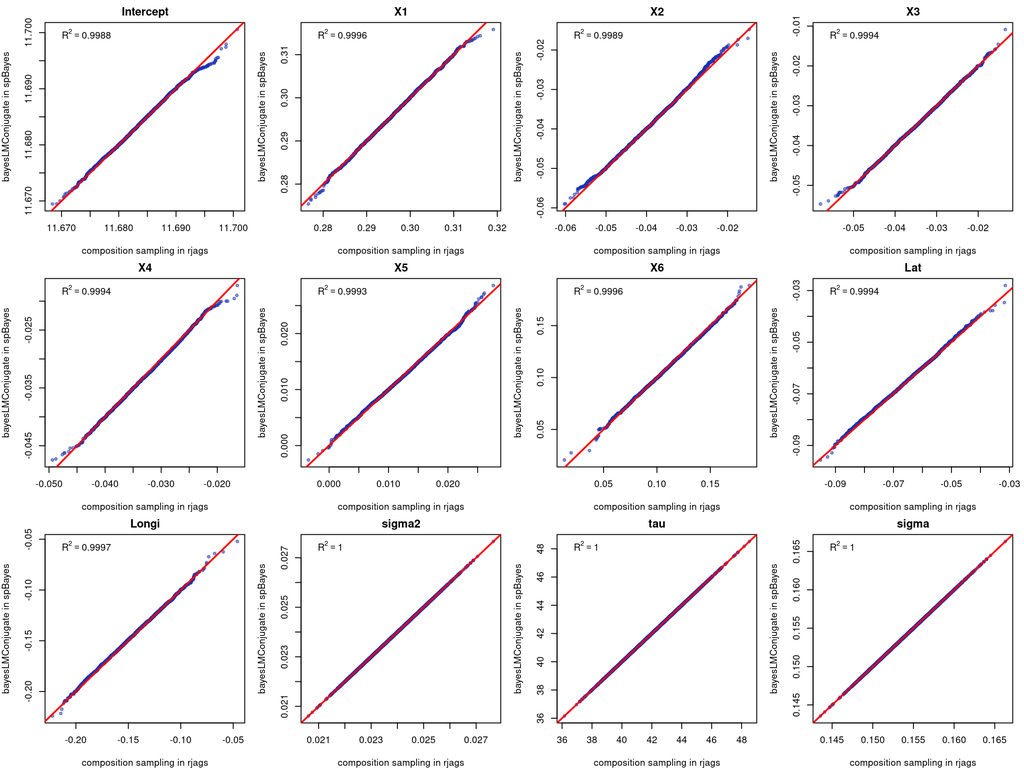

```r
par(mfrow = c(3, 4), mar = c(4, 4, 2, 1))
param_names <- colnames(jags_rep)

for (param in param_names) {
  x_jags    <- sort(jags_rep[, param])
  y_spbayes <- sort(spb_samples1[, param])
  r2        <- cor(x_jags, y_spbayes)^2

  plot(x_jags, y_spbayes,
       main = param,
       xlab = "composition sampling in rjags",
       ylab = "bayesLMConjugate in spBayes",
       pch = 20, col = rgb(0.1, 0.2, 0.7, alpha = 0.5))

  abline(a = 0, b = 1, col = "red", lwd = 2)
  legend("topleft", legend = bquote(R^2 == .(format(r2, digits = 4))),
         bty = "n", text.col = "black")
}
```

```r
par(mfrow = c(1, 1))

# Save PNG copy to disk
dev.copy(png, "comparisonsJagsVsSpBayesQ-Qplots.png", width = 1200, height = 900, res = 150)
```

```r
dev.off()
```

## 5. Direct JAGS vs. `spBayes::bayesLMConjugate`

Finally, we validate the Direct JAGS composition sampler against `spBayes::bayesLMConjugate()`.

```r
# 1. Run Direct JAGS
set.seed(123)
jags_dir <- run_direct_jags_composition(
  X = X, Y = Y, n_samples = n_samples,
  a0 = a0, b0 = b0, m0 = m0, M0_inv = M0_inv
)$draws

# 2. Run spBayes
set.seed(123)
spb_model_2 <- bayesLMConjugate(
  formula = Y ~ ., data = df, n.samples = n_samples,
  beta.prior.mean = rep(0, P),
  beta.prior.precision = M0_inv,
  prior.shape = a0, prior.rate = b0
)

# Extract and align spBayes parameter columns
spb_raw2     <- spb_model_2$p.beta.tauSq.samples
spb_var2     <- spb_raw2[, P + 1]
spb_sigma2   <- sqrt(spb_var2)
spb_tau2     <- 1 / spb_var2

spb_samples2 <- cbind(spb_raw2[, 1:P], sigma2 = spb_var2, tau = spb_tau2, sigma = spb_sigma2)
colnames(spb_samples2) <- colnames(jags_dir)

# Display Posterior Summaries
s_jags_dir <- round(cbind(Mean = colMeans(jags_dir), SD = apply(jags_dir, 2, sd),
                           crossprod(apply(jags_dir, 2, quantile, probs = c(0.5, 0.025, 0.975)), diag(3))), 4)

s_spb2     <- round(cbind(Mean = colMeans(spb_samples2), SD = apply(spb_samples2, 2, sd),
                           crossprod(apply(spb_samples2, 2, quantile, probs = c(0.5, 0.025, 0.975)), diag(3))), 4)

kable(s_jags_dir, caption = "Posterior Summary: Direct JAGS Sampler")
```

Posterior Summary: Direct JAGS Sampler

|  | Mean | SD |  |  |  |
| --- | --- | --- | --- | --- | --- |
| Intercept | 11.6840 | 0.0042 | 11.6841 | 11.6759 | 11.6922 |
| X1 | 0.2963 | 0.0059 | 0.2964 | 0.2850 | 0.3078 |
| X2 | -0.0385 | 0.0061 | -0.0385 | -0.0505 | -0.0266 |
| X3 | -0.0347 | 0.0058 | -0.0347 | -0.0459 | -0.0230 |
| X4 | -0.0329 | 0.0042 | -0.0329 | -0.0412 | -0.0245 |
| X5 | 0.0128 | 0.0041 | 0.0128 | 0.0047 | 0.0210 |
| X6 | 0.1114 | 0.0219 | 0.1115 | 0.0682 | 0.1545 |
| Lat | -0.0648 | 0.0085 | -0.0648 | -0.0816 | -0.0481 |
| Longi | -0.1454 | 0.0224 | -0.1453 | -0.1891 | -0.1008 |
| sigma2 | 0.0238 | 0.0009 | 0.0237 | 0.0220 | 0.0257 |
| tau | 42.1324 | 1.6519 | 42.1334 | 38.9797 | 45.3545 |
| sigma | 0.1541 | 0.0030 | 0.1541 | 0.1485 | 0.1602 |

```r
kable(s_spb2, caption = "Posterior Summary: spBayes::bayesLMConjugate")
```

Posterior Summary: spBayes::bayesLMConjugate

|  | Mean | SD |  |  |  |
| --- | --- | --- | --- | --- | --- |
| Intercept | 11.6840 | 0.0041 | 11.6841 | 11.6758 | 11.6918 |
| X1 | 0.2964 | 0.0059 | 0.2964 | 0.2847 | 0.3081 |
| X2 | -0.0386 | 0.0062 | -0.0388 | -0.0505 | -0.0261 |
| X3 | -0.0347 | 0.0059 | -0.0347 | -0.0462 | -0.0230 |
| X4 | -0.0328 | 0.0043 | -0.0329 | -0.0412 | -0.0243 |
| X5 | 0.0128 | 0.0041 | 0.0127 | 0.0048 | 0.0210 |
| X6 | 0.1112 | 0.0215 | 0.1108 | 0.0687 | 0.1531 |
| Lat | -0.0648 | 0.0084 | -0.0649 | -0.0812 | -0.0478 |
| Longi | -0.1452 | 0.0220 | -0.1452 | -0.1878 | -0.1019 |
| sigma2 | 0.0238 | 0.0009 | 0.0238 | 0.0221 | 0.0257 |
| tau | 42.0868 | 1.5894 | 42.0699 | 38.9838 | 45.2475 |
| sigma | 0.1542 | 0.0029 | 0.1542 | 0.1487 | 0.1602 |

### Diagnostics: Q-Q Plots ($R^2$ Comparison)

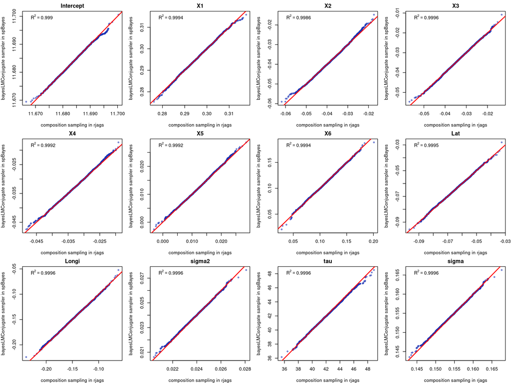

```r
par(mfrow = c(3, 4), mar = c(4, 4, 2, 1))
param_names <- colnames(jags_dir)

for (param in param_names) {
  x_jags    <- sort(jags_dir[, param])
  y_spbayes <- sort(spb_samples2[, param])
  r2        <- cor(x_jags, y_spbayes)^2

  plot(x_jags, y_spbayes,
       main = param,
       xlab = "composition sampling in rjags",
       ylab = "bayesLMConjugate sampler in spBayes",
       pch = 20, col = rgb(0.1, 0.2, 0.7, alpha = 0.5))

  abline(a = 0, b = 1, col = "red", lwd = 2)
  legend("topleft", legend = bquote(R^2 == .(format(r2, digits = 4))),
         bty = "n", text.col = "black")
}
```

```r
par(mfrow = c(1, 1))

# Save PNG copy to disk
dev.copy(png, "comparisonsJagsDirectVsSpBayesQ-Qplots.png", width = 1200, height = 900, res = 150)
```

```r
dev.off()
```